# Analiza EDA

Zuzanna Bosak

2023-11-26

# Wprowadzenie

Wybrany przeze mnie zbiór danych to zestaw *sport_e2*. Jest to badanie pewnej studentki, która przeprowadziła ankietę potrzebną do jej pracy licencjackiej. Stworzyła formularz online skierowany do sportowców różnych dyscyplin. Interesował ją przede wszystkim związek między sportem, który trenują, a cechą osobowości zaliczaną do Self-Construal Scale (Ted Singelis, 1994). Skala ta w uproszczeniu określa to w jaki sposób widzimy siebie w relacji do innych ludzi. Badanie składa się z 30 pytań. 15 z nich mierzy to w jakim stopniu człowiek widzi siebie jako osobną i niezależną jednostkę. Na tej podstawie, w 7-stopniowej skali wyznaczany jest współczynnik *“independence”*. Kolejne 15 pytań bada w jakim stopniu odpowiadający widzi siebie jako kogoś ściśle połączonego z otoczeniem. W tej samej 7-stopniowej skali wyznaczany jest współczynnik *“interdependence”*. Ta idea niezmiernie mnie zainteresowała. Postanowiłam więc na własną rękę zbadać powiązane z tym zależności oraz pochylić się nad innymi kwestiami wykorzystując zebrane dane. Tak narodził się pomysł na taką a nie inną analizę EDA.

# Zmienne

- **Index** (liczbowo, numer kwestionariusza)
- **Importance** (liczbowo, odpowiedź na pytanie: “Jak ważny jest dla ciebie sport”, skala 1-7)
- **Sport** (tekst, odpowiedź na pytanie: “Z jaką trenowaną dyscypliną sportową utożsamiasz się najbardziej)
- **Frequency** (liczbowo, odpowiedź na pytanie “Jak często uprawiasz sport”, skala 1-8, gdzie 1 to mniej niż raz w tygodniu, 2 - raz w tygodniu,…,8 - codziennie)
- **How_alone** (tekst, odpowiedzi TRUE/FALSE na pytanie “Czy wolisz trenować samemu?”)
- **How_small_groups** (tekst, odpowiedzi TRUE/FALSE na pytanie “Czy wolisz trenować w małych grupach?”)
- **How_big_groups** (tekst, odpowiedzi TRUE/FALSE na pytanie “Czy wolisz trenować w dużych grupach?”)
- **Independence** (liczbowo, opisany wyżej współczynnik *“independence”*, skala 1-7)
- **Interdependence** (liczbowo, opisany wyżej współczynnik *“interdependence”*, skala 1-7)
- **Sex** (tekst, płeć odpowiadającego: F- kobieta, M- mężczyzna)
- **Age** (liczbowa, wiek odpowiadającego)
- **Education** (liczbowa, poziom edukacji odpowiadającego)

# Pakiety

Pakiety, które będę używała:

```r
library(mice)
library(dplyr)
library(ggplot2)
library(corrplot)
library(gridExtra)
library(RColorBrewer)
```

Wczytuję wybrany zestaw danych.

```r
sport_e2 <- read.csv("C:/Users/zuzia/Downloads/archive (1)/sport_e2.csv")
```

# Zapoznanie z danymi

Zaczynam od wyświetlenia kilku pierwszych wierszy, aby rozpocząć zapoznawanie się z moim zestawem danych

```r
head(sport_e2)
```

```
##   index importance                 sport frequency how_alone how_small_groups
## 1   134          7 Martial Arts Tricking         5     False             True
## 2   135          7 Martial Arts Tricking         5      True             True
## 3   137          7            Basketball         4      True             True
## 4   139          7               Parkour         7      True             True
## 5   140          7               Parkour         6     False             True
## 6   142          7           Freerunning         3     False             True
##   how_big_groups independence interdependence sex age education
## 1          False     4.000000        5.833333   m  26         7
## 2           True     5.416667        6.583333   m  25         5
## 3           True     4.166667        5.916667   m  27         8
## 4          False     4.666667        5.583333   m  18         4
## 5          False     4.833333        5.833333   m  19         7
## 6          False     2.750000        2.083333   m  18         9
```

Sprawdzę również strukturę pliku. Najbardziej interesują mnie typy zmiennych.

```r
str(sport_e2)
```

```
## 'data.frame':    399 obs. of  12 variables:
##  $ index           : int  134 135 137 139 140 142 143 144 150 151 ...
##  $ importance      : int  7 7 7 7 7 7 7 7 7 7 ...
##  $ sport           : chr  "Martial Arts Tricking" "Martial Arts Tricking" "Basketball" "Parkour" ...
##  $ frequency       : int  5 5 4 7 6 3 6 5 8 5 ...
##  $ how_alone       : chr  "False" "True" "True" "True" ...
##  $ how_small_groups: chr  "True" "True" "True" "True" ...
##  $ how_big_groups  : chr  "False" "True" "True" "False" ...
##  $ independence    : num  4 5.42 4.17 4.67 4.83 ...
##  $ interdependence : num  5.83 6.58 5.92 5.58 5.83 ...
##  $ sex             : chr  "m" "m" "m" "m" ...
##  $ age             : int  26 25 27 18 19 18 16 25 17 17 ...
##  $ education       : int  7 5 8 4 7 9 9 6 4 9 ...
```

Widzę, że zmienne zawierające odpowiedzi TRUE/FALSE zaklasyfikowane zostały jako zmienne tekstowe. Przekształcę je w zmienne logiczne. Zapiszę również zmienną określającą płeć jako faktor.

```r
sport_e2$how_alone <- as.logical(sport_e2$how_alone)
sport_e2$how_small_groups <- as.logical(sport_e2$how_small_groups)
sport_e2$how_big_groups <- as.logical(sport_e2$how_big_groups)
sport_e2$sex <- as.factor(sport_e2$sex)
```

Upewnię się, czy nie mam do czynienia z brakami danych.

```
##  /\     /\
## {  `---'  }
## {  O   O  }
## ==>  V <==  No need for mice. This data set is completely observed.
##  \  \|/  /
##   `-----'
```

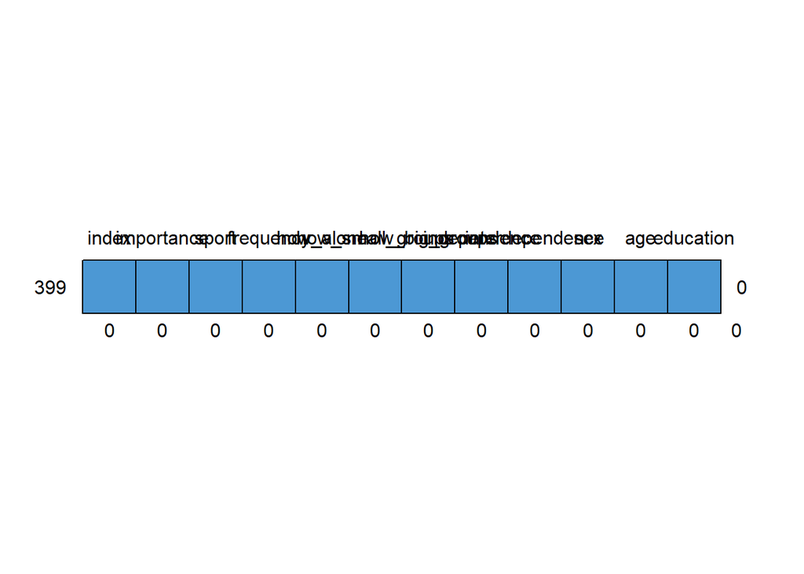

```
##     index importance sport frequency how_alone how_small_groups how_big_groups
## 399     1          1     1         1         1                1              1
##         0          0     0         0         0                0              0
##     independence interdependence sex age education
## 399            1               1   1   1         1 0
##                0               0   0   0         0 0
```

```r
md.pattern(sport_e2)
```

Mam szczęście - nie zaobserwowano żadnych braków danych. Nie będą więc wpływać na moje obliczednia.

Chciałabym teraz przyjrzeć się wskazywanym przez ankietowanych dyscyplinom sportowych.

```r
table(sport_e2$sport)
```

```
##
##            Acrobatics              Aerobics   Alpha Combat System
##                     1                     1                     1
##             Badminton            Basketball      Beach Volleyball
##                     3                    28                     1
##                   BJJ          Bodybuilding                Boxing
##                     3                     6                     1
##          Calisthenics              Capoeira  Chinese Martial Arts
##                     1                     1                     1
##              Climbing          Combat Sport               Cycling
##                     4                     5                     3
##                 Dance         Equestrianism               Escrima
##                    11                     4                     1
##               Fencing         Fitness Sport              Football
##                     2                     9                     2
##           Freerunning            Gymnastics              Handball
##                     6                    31                    35
##                Hockey           Ice-Skating          Jeet kune do
##                     4                     1                     1
##                  Judo                 Kapap                Karate
##                     5                     1                     5
##              Kenjutsu            Kickboxing               Kung Fu
##                     1                     3                     1
##              Lacrosse Martial Arts Tricking                   MMA
##                     1                     5                     4
##        Mountainbiking             Muay Thai              Ninjutsu
##                     2                     3                     2
##               Parkour           Power Sport        Roller Blading
##                    45                     6                     1
##                Rowing                 Rugby               Running
##                     2                     1                    10
##                Skiing           Slacklining          Snowboarding
##                     2                     1                     3
##                Soccer              Swimming          Table Tennis
##                    65                    11                     2
##             Taekwondo                Tennis       Track and Field
##                     2                     5                    23
##            Trampoline             Triathlon            Volleyball
##                     1                     2                    12
##             Wing Chun                  Yoga
##                     4                     1
```

Już widzę, że występują duże różnice w liczności wybieranych sportów. Dla czytelności zwizualizuję 10 najczęściej wskazywanych dyscyplin.

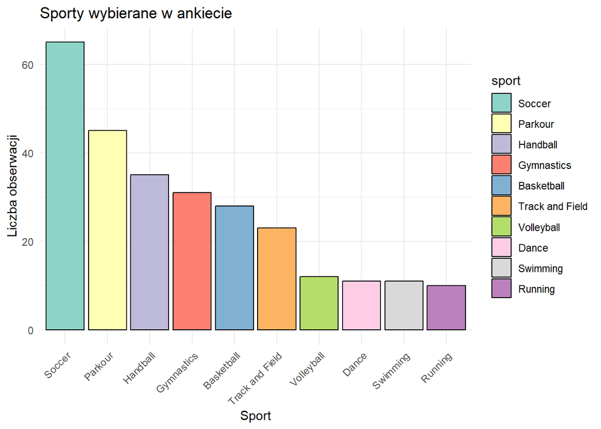

```r
sport_e2 %>%
  count(sport) %>%
  top_n(10, n) %>%
  mutate(sport = reorder(sport, desc(n))) %>%
  ggplot() +
  geom_bar(mapping = aes(x = sport, y = n, fill = sport),
           stat = "identity",
           colour = "black") +
  scale_fill_brewer(palette = "Set3") +
  theme_minimal() +
  labs(title = "Sporty wybierane w ankiecie",
       x = "Sport",
       y = "Liczba obserwacji") +
  theme(axis.text.x = element_text(angle = 45, hjust = 1))
```

Ten wykres tylko potwierdza spore dysproporcje w liczbie odpowiedzi na pytanie o uprawianą dyscyplinę sportu. Postanowiłam więc nie badać kolejnych zależności z konkretnym sportem, a zamiast tego pogrupować je w 3 kategorie - sporty zespołowe, indywidualne, oraz te charakteryzujące się rywalizacją 1 na 1.

```r
sport_e2 <- sport_e2 %>%
  mutate(sports_category = case_when(
    sport %in% c("Acrobatics", "Climbing", "Equestrianism", "Mountainbiking", "Power Sport", "Running",
                 "Aerobics", "Calisthenics", "Freerunning", "Ice-Skating"," Roller Blading", "Skiing",
                 "Swimming", "Track and Field", "Cycling", " Gymnastics", "Martial Arts Tricking", "Slacklining", "Trampoline",
                 "Yoga", "Bodybuilding", "Dance", "Fitness Sport", "Parkour", "Snowboarding", "Triathlon" ) ~ "Sporty indywidualne",
    sport %in% c("Basketball", "Football", "Hockey","Soccer", "Volleyball", "Beach Volleyball",
                 "Lacrosse", "Rowing", "Handball") ~ "Sporty Zespołowe",
    TRUE ~ "Rywalizacja 1 na 1"
  ))
```

W moim zestawie danych stworzona została więc nowa kategoria *sports_category*.

```r
table(sport_e2$sports_category)
```

```
##
##  Rywalizacja 1 na 1 Sporty indywidualne    Sporty Zespołowe
##                  90                 159                 150
```

Teraz zróżnicowanie między licznością kategorii jest już mniejsze. Jestem w stanie zaakceptować taki rozkład.

Przyjrzę się jeszcze statystykom opisowym wszystkich zmiennych

```r
summary(sport_e2)
```

```
##      index         importance       sport             frequency
##  Min.   :134.0   Min.   :1.000   Length:399         Min.   :1.000
##  1st Qu.:307.5   1st Qu.:6.000   Class :character   1st Qu.:4.000
##  Median :533.0   Median :7.000   Mode  :character   Median :5.000
##  Mean   :531.3   Mean   :6.619                      Mean   :5.308
##  3rd Qu.:747.5   3rd Qu.:7.000                      3rd Qu.:6.000
##  Max.   :960.0   Max.   :7.000                      Max.   :8.000
##  how_alone       how_small_groups how_big_groups   independence
##  Mode :logical   Mode :logical    Mode :logical   Min.   :2.417
##  FALSE:276       FALSE:109        FALSE:285       1st Qu.:4.167
##  TRUE :123       TRUE :290        TRUE :114       Median :4.667
##                                                   Mean   :4.570
##                                                   3rd Qu.:5.000
##                                                   Max.   :6.500
##  interdependence sex          age          education     sports_category
##  Min.   :2.083   f:148   Min.   :12.00   Min.   :1.000   Length:399
##  1st Qu.:4.667   m:251   1st Qu.:20.00   1st Qu.:7.000   Class :character
##  Median :5.167           Median :23.00   Median :7.000   Mode  :character
##  Mean   :5.080           Mean   :23.76   Mean   :7.113
##  3rd Qu.:5.583           3rd Qu.:25.00   3rd Qu.:8.000
##  Max.   :6.917           Max.   :70.00   Max.   :9.000
```

# Związki między zmiennymi numerycznymi

Zacznę od sprawdzenia rozkładów zmiennych numerycznych.

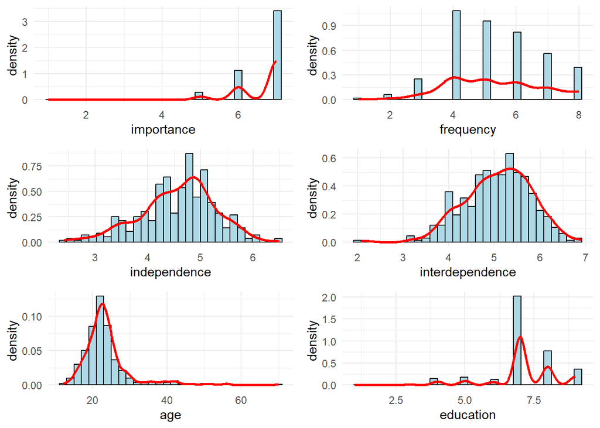

```r
numeryczne_dane <- sport_e2 %>%
    select_if(is.numeric) %>%
  select(-index)
plot_histogram <- function(data, variable) {
    ggplot(data, aes(x = !!rlang::sym(variable))) +
      geom_histogram(aes(y = ..density..), bins = 30, fill = "lightblue", color = "black") +
      geom_density(color = "red", size = 1) +
      theme_minimal()
  }
  plots_list <- list()
  for (col in names(numeryczne_dane)) {
    plots_list[[col]] <- plot_histogram(sport_e2, col)
  }
  grid.arrange(grobs = plots_list, ncol = 2)
```

Widać, że zmienne numeryczne nie mają rozkładów normalnych. Żeby policzyć korelacje muszę więc użyć współczynnika korelacji Spearmana.

W tym podpunkcie zadałam sobie trzy pytania badawcze:

## Czy waga, jaką przykładamy do danego sportu rzeczywiście przekłada się na częstotliwość jego trenowania?

## Czy z wiekiem nasze priorytety się zmieniają i przykładamy mniejszą wagę do sportu?

## Czy im jesteśmy starsi, tym trenujemy coraz mniej?

Te związki wydają mi się najbardziej prawdopodobne, ale może zaskoczy mnie coś zupełnie innego.

```r
korelacja_spearmana <- cor(numeryczne_dane, method = "spearman")
korelacja_spearmana
```

```
##                  importance    frequency independence interdependence
## importance       1.00000000  0.427770585  0.047830461      0.20489854
## frequency        0.42777059  1.000000000 -0.005168621      0.23589415
## independence     0.04783046 -0.005168621  1.000000000      0.03969298
## interdependence  0.20489854  0.235894146  0.039692979      1.00000000
## age             -0.11655157 -0.098932570 -0.192491092     -0.02184434
## education       -0.05021791 -0.063792113 -0.054799668      0.03131720
##                         age   education
## importance      -0.11655157 -0.05021791
## frequency       -0.09893257 -0.06379211
## independence    -0.19249109 -0.05479967
## interdependence -0.02184434  0.03131720
## age              1.00000000  0.03140217
## education        0.03140217  1.00000000
```

W przypadku tego zestawu danych nie sprawdziła się moja hipoteza, że z wiekiem znacznie zmniejsza się częstotliwość treningu. Ujemna korelacja jest zauważalna, ale bardzo niska (-0,099). Spodziewałam się także większej ujemnej korelacji między wiekiem a “poziomem istotności” sportu. Wynosi ona w przybliżeniu -0,12. Zakładałam, że z wiekiem zmieniają nam się priorytety i sport odchodzi na dalszy plan.

Upewnię się, że nie przeoczyłam żadnego istotego związku tworząc macierz korelacji.

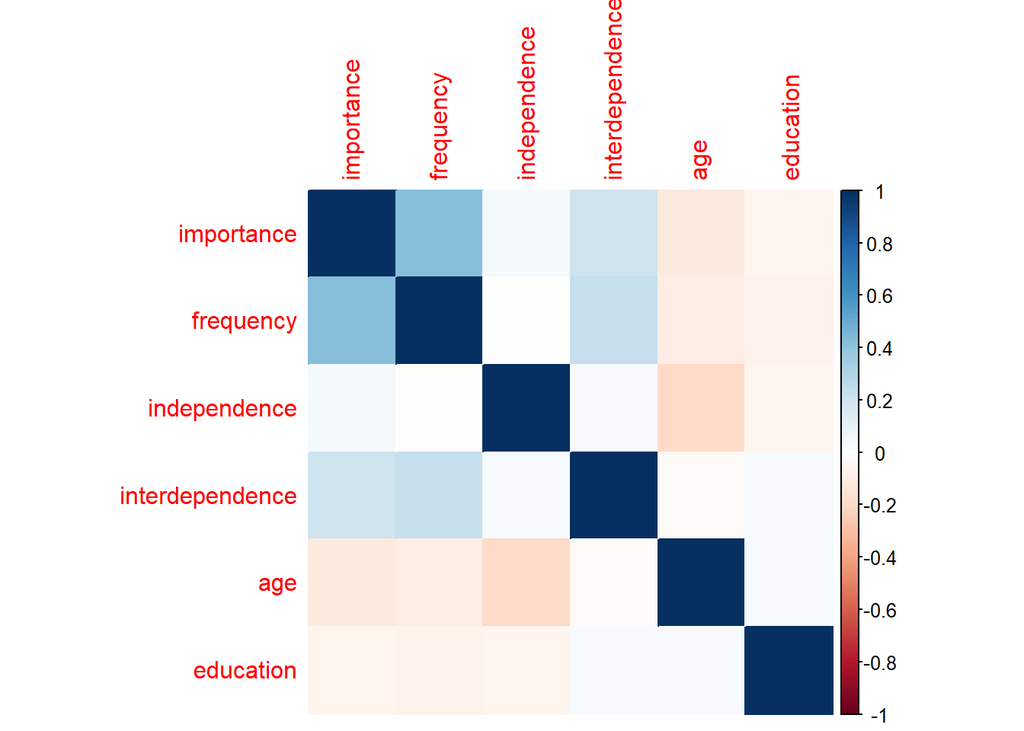

```r
corrplot(korelacja_spearmana, method = "color")
```

# Kategoria trenowanego sportu a Self-Construal Scale

Kolejnym tematem, który chcę zbadać jest związek między kategorią trenowanej dyscypliny, a wynikami psychologicznego testu Self-Construal Scale. Czy przy wyborze ludzie podświadomie kierują się tym czynnikiem? Nie wgłębiając się w badania, wydawałoby się, że ludzie o wyższym poziomie cechy *independence* powinni wybierać sporty indywidualne i “rywalizację 1 na 1” a ci o wyższym poziomie cechy *interdependence* sporty zespołowe. Sprawdźmy czy tak jest w rzeczywistości.

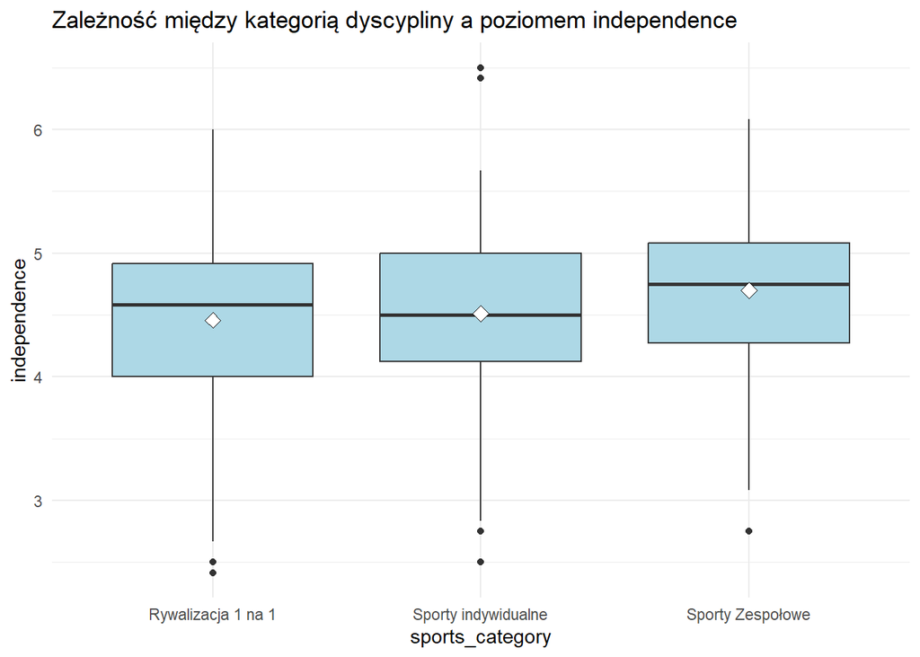

```r
ggplot(sport_e2, aes(x = sports_category, y = independence)) +
    geom_boxplot(fill = "lightblue") +
    stat_summary(fun.y = "mean", geom = "point", shape = 23, size = 3, fill = "white") +
    ggtitle("Zależność między kategorią dyscypliny a poziomem independence") +
    theme_minimal()
```

Wizualizacja przedstawia medianę (linia pozioma) oraz (dodaną przeze mnie) średnią (romb) współczynników *independence* w danych kategoriach. Wygląda na to, że wyższe wyniki w teście poziomu *independence* uzyskują, zaskakująco, osoby uprawiające sporty zespołowe. Mimo dużego zróżnicowania w liczności odpowiedzi postanowiłam jednak zweryfikować ten rezultat i wyświetlić już nie kategorie, a 10 dyscyplin, których zawodnicy mają najwyższy wynik testu *independence*.

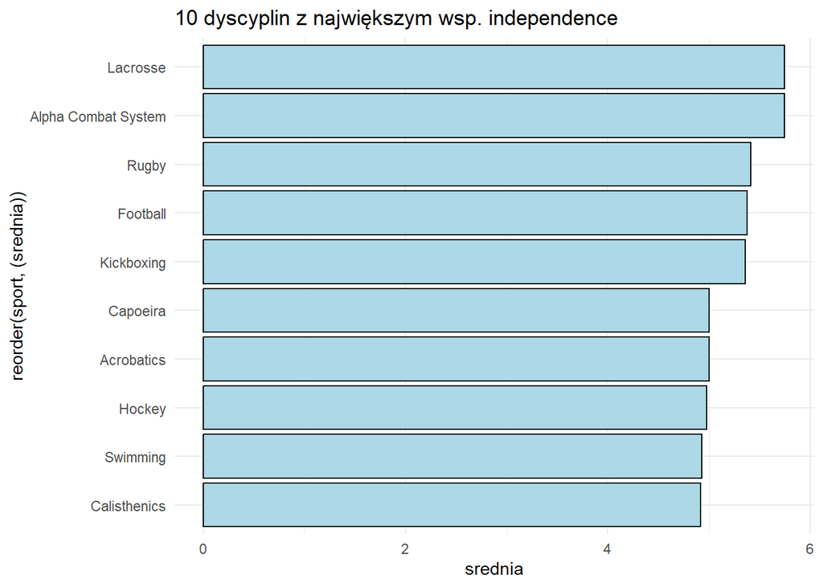

```r
sport_e2 %>%
    group_by(sport) %>%
    summarize(srednia = mean(independence)) %>%
    arrange(desc(srednia)) %>%
    head(10) %>%
    ggplot(aes(x = reorder(sport, (srednia)), y = srednia)) +
    geom_col(fill = "lightblue", color = "black") +
    coord_flip() +
    ggtitle("10 dyscyplin z największym wsp. independence") +
    theme_minimal()
```

Rzeczywiście w czołówce widzimy sporty zespołowe (Lacrosse, Rugby, Football, Hockey). Wygląda na to, że ten czynnik psychologiczny **nie jest** faktorem decydującym. Prawdopodobnie przy wyborze bardziej liczy się miejsca zamieszkania, popularność, perspektywy rozwoju, czy preferencje rodziców. Zagłębiając się jednak w badania uniwersytetu Stanforda przeczytałam, że grupy osób o przeważającej cesze *interdependence* są znacznie skuteczniejsze niż grupy osób o cesze *independence*, ponieważ współpracują bardziej świadomie i etycznie (Bell, 2007; Woolley, et al., 2010). Może więc warto pomyśleć nad wprowadzeniem tego testu przy rekrutacji zawodników do drużyn sportowych?

Zobaczmy teraz jaka zależność występuje między kategorią trenowanego sportu a poziomem *interdependence* zawodników.

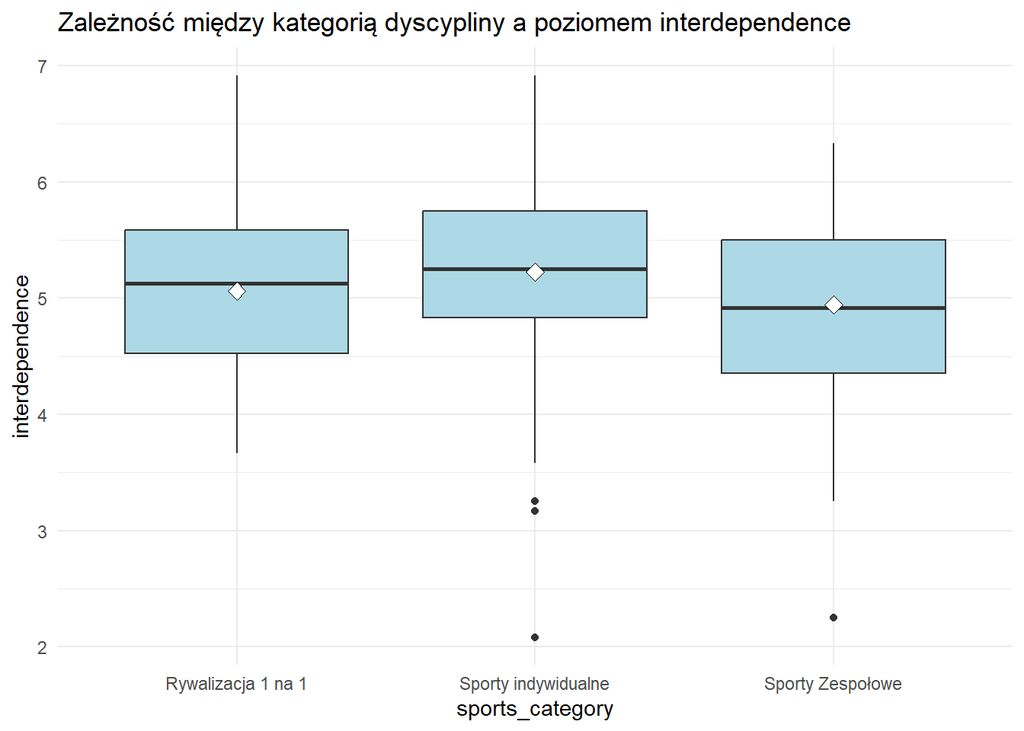

```r
ggplot(sport_e2, aes(x = sports_category, y = interdependence)) +
      geom_boxplot(fill = "lightblue") +
      stat_summary(fun.y = "mean", geom = "point", shape = 23, size = 3, fill = "white") +
      ggtitle("Zależność między kategorią dyscypliny a poziomem interdependence") +
      theme_minimal()
```

W tym przypadku wyniki również są zupełnie odwrotne od oczekiwanych. To średnio zawodnicy **sportów indywidualnych** osiągają najwyższe wyniki w teście cechy *interdependence*. Teraz pytanie, czy to kwestia tej konkretnej próby statystycznej, czy podświadomie wybieramy sport, który wymaga od nas cechy odwrotnej? Rezultaty bardzo mnie zaskoczyły, ale czynią to zagadnienie jeszcze ciekawszym.

Spójrzmy na 10 dyscyplin, w których współczynnik *interdependence* zawodników jest najwyższy.

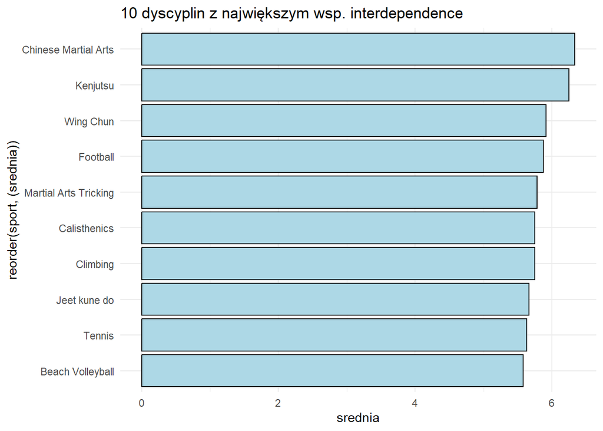

```r
sport_e2 %>%
      group_by(sport) %>%
      summarize(srednia = mean(interdependence)) %>%
      arrange(desc(srednia)) %>%
      head(10) %>%
      ggplot(aes(x = reorder(sport, (srednia)), y = srednia)) +
      geom_col(fill = "lightblue", color = "black") +
      coord_flip() +
      ggtitle("10 dyscyplin z największym wsp. interdependence") +
      theme_minimal()
```

Przodują sztuki walki (zaklasyfikowane do rywalizacji 1vs1) oraz sporty indywidualne. Wysoko jest football amerykański oraz siatkówka plażowa, ale to dwie jedyne dyscypliny zespołowe w tym zestawieniu.

# Czy poziom współczynnika independence wpływa na to, że wolimy trenować samemu?

Interesowało mnie również, czy poziom współczynnika *independence* wpływa na to, że wolimy trenować samemu.

```r
tapply(sport_e2$how_alone, cut(sport_e2$independence, breaks = 3), mean)
```

```
## (2.41,3.78] (3.78,5.14]  (5.14,6.5]
##   0.4833333   0.2633588   0.3246753
```

Wynika z tego, że trenować samemu wolą osoby o niższym (2.41-3.78) poziomie współczynnika *independence*. Może na to wpływać jednak charakter trenowanej przez nich dyscypliny.

# Czy poziom współczynnika interdependence wpływa na to, że wolimy trenować w większych grupach?

Kolejne badanie jest analogiczne. Czy osoby, które cechują się “większą zależnością od innych” rzeczywiście wolą trenować w dużych grupach?

```r
tapply(sport_e2$how_big_groups, cut(sport_e2$interdependence, breaks = 3), mean)
```

```
## (2.08,3.69] (3.69,5.31] (5.31,6.92]
##   0.4166667   0.2672811   0.3000000
```

I znów otrzymuję wyniki odwrotne od oczekiwanych! To ludzie o najniższym poziomie *interdependence* najczęściej odpowiadali, że lubią trenować w dużych grupach. Znowu może to wynikać z charakteru trenowanej przez nich dyscypliny, a może w sporcie szukają czegoś zupełnie innego od swoich preferencji osobowościowych?

# Płeć, a poziom independence

Zastanawiałam się, czy płeć ma wpływ na poziom współczynników testu Self-Construal. Sprawdzę to za pomocą wizualizacji.

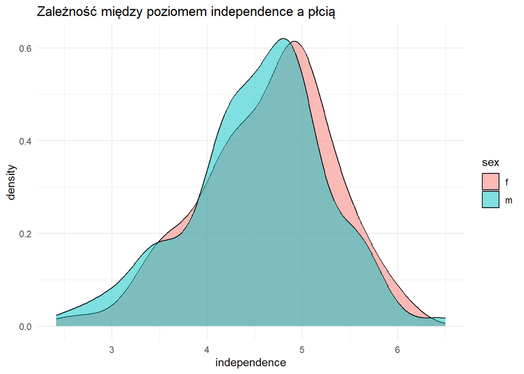

```r
ggplot(sport_e2, aes(x = independence, fill = sex)) +
      geom_density(alpha = 0.5) +
      ggtitle("Zależność między poziomem independence a płcią") +
      theme_minimal()
```

Z wykresu gęstości wynika, że nieznacznie wyższy poziom cechy *independence* osiągają kobiety (nie mogę powiedzieć, że jestem zaskoczona).

# Płeć, a poziom interdependence

To samo badanie przeprowadziłam dla współczynnika *interdependence*.

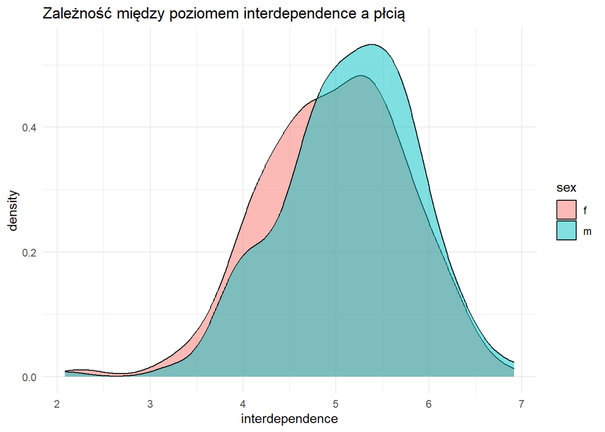

```r
ggplot(sport_e2, aes(x = interdependence, fill = sex)) +
      geom_density(alpha = 0.5) +
      ggtitle("Zależność między poziomem interdependence a płcią") +
      theme_minimal()
```

W przypadku współczynnika *interdependecne* nieco wyższe wyniki osiągają mężczyźni.

# Czy cechy *independence* i *interdependence* wykluczają się wzajemnie?

Chciałam również sprawdzić, czy możliwe jest osiąganie wysokich wyników zarówno w teście poziomu *independence* jak i *interdependence*, czy te z reguły wykluczają się wzajemnie. Użyłam do tego wykresu punktowego.

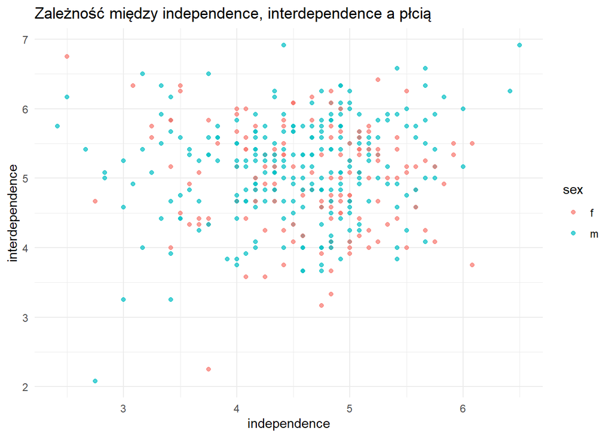

```r
 ggplot(sport_e2, aes(x = independence, y = interdependence, color = sex)) +
      geom_point(alpha = 0.7) +
      ggtitle("Zależność między independence, interdependence a płcią") +
      theme_minimal()
```

Widzimy obserwacje, które osiągają wysokie wyniki w obu testach. Szczególnie jedna z nich jest niezwykle imponująca. Ankietowany uzyskał wynik bliski 7 współczynnika *interdependence* oraz wartość 6,5 współczynnika *independence*. Kolejna zauważalna rzecz to fakt, że skrajne obserwacje należą raczej do mężczyzn.

# Zależność między płcią a kategorią trenowanej dyscypliny.

Self-Construal Scale to nie jedyne co interesowało mnie w przypadku tego zestawu danych. Kolejne pytanie, które sobie zadałam to czy płeć ma wpłw na wybór kategorii trenowanej dyscypliny. Domyślałam się, że odsetek kobiet w każdej kategorii będzie mniejszy niż odsetek mężczyzn (ze względu na przewagę mężczyzn wśród ankietowanych), chciałam jednak zobaczyć, w którym przypadku ta różnica będzie najmniejsza.

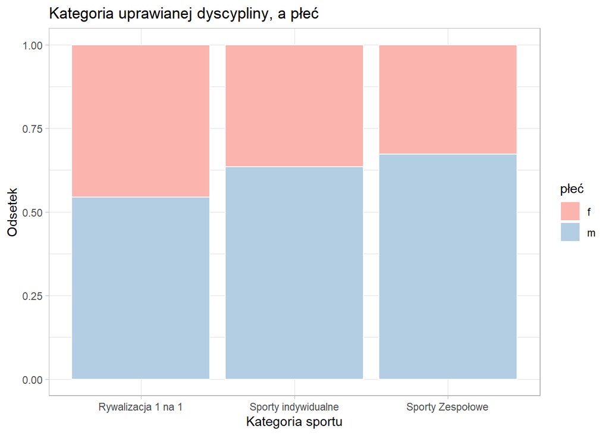

```r
sport_e2 %>%
      ggplot() +
      geom_bar(aes(x = sports_category, fill = sex),
               color = "white",
               position = "fill") +
      scale_fill_brewer(palette = "Pastel1") +
      theme_light() +
      labs(title = "Kategoria uprawianej dyscypliny, a płeć",
           x = "Kategoria sportu",
           y = "Odsetek",
           fill = "płeć")
```

Jak widać najmniejszą różnicę odsetka kobiet i mężczyzn obserwujemy w przypadku sportów charakteryzujących się rywalizacją 1 na 1. Największa przewaga mężczyzn występuję w przypadku sportów zespołowych.

# Podsumowanie

Wyniki mojego badania w dużej mierze okazały się zaskakujące. Uwarunkowania psychologiczne ankietowanych okazywały się zupełnie odwrotne do ich wyborów sportowych i zwyczajów treningowych. Rezultaty pozostawiają ogromną przestrzeń do dalszych rozważań. Może podświadomie chcemy udoskonalać te cechy, w których mamy “większe braki”? A może taką potrzebę widzą rodzice wysyłając swoje dzieci na ich pierwsze zajęcia? Tak czy inaczej, potwierdziło się na pewno, że nic w psychologii nie jest proste i oczywiste.